Skip to content

# Computing RNA Expression Similarity

## Download the Data

First we need to download the data set we will use. We are going to use the TCGA data here since it is publically available and well known (UCSC Xena TCGA PANCAN). We will download the TPM matrix as well as the corresponding metadata file

```
!wget https://toil-xena-hub.s3.us-east-1.amazonaws.com/download/tcga_RSEM_gene_tpm.gz
!wget https://tcga-pancan-atlas-hub.s3.us-east-1.amazonaws.com/download/Survival_SupplementalTable_S1_20171025_xena_sp
```

```
--2021-06-10 17:34:56--  https://toil-xena-hub.s3.us-east-1.amazonaws.com/download/tcga_RSEM_gene_tpm.gz
Resolving toil-xena-hub.s3.us-east-1.amazonaws.com (toil-xena-hub.s3.us-east-1.amazonaws.com)... 52.216.136.30
Connecting to toil-xena-hub.s3.us-east-1.amazonaws.com (toil-xena-hub.s3.us-east-1.amazonaws.com)|52.216.136.30|:443... connected.
HTTP request sent, awaiting response... 200 OK
Length: 740772247 (706M) [binary/octet-stream]
Saving to: ‘tcga_RSEM_gene_tpm.gz’

tcga_RSEM_gene_tpm. 100%[===================>] 706.46M  15.5MB/s    in 49s

2021-06-10 17:35:46 (14.5 MB/s) - ‘tcga_RSEM_gene_tpm.gz’ saved [740772247/740772247]

--2021-06-10 17:35:46--  https://tcga-pancan-atlas-hub.s3.us-east-1.amazonaws.com/download/Survival_SupplementalTable_S1_20171025_xena_sp
Resolving tcga-pancan-atlas-hub.s3.us-east-1.amazonaws.com (tcga-pancan-atlas-hub.s3.us-east-1.amazonaws.com)... 52.216.94.142
Connecting to tcga-pancan-atlas-hub.s3.us-east-1.amazonaws.com (tcga-pancan-atlas-hub.s3.us-east-1.amazonaws.com)|52.216.94.142|:443... connected.
HTTP request sent, awaiting response... 200 OK
Length: 2419504 (2.3M) [binary/octet-stream]
Saving to: ‘Survival_SupplementalTable_S1_20171025_xena_sp’

Survival_Supplement 100%[===================>]   2.31M  1.75MB/s    in 1.3s

2021-06-10 17:35:48 (1.75 MB/s) - ‘Survival_SupplementalTable_S1_20171025_xena_sp’ saved [2419504/2419504]
```

## Install Dependencies

For the following tutorial we are going to use some common data processing and visualization libraries in python: seaborn and pandas. We need to install them before we proceed

```
!pip install pandas seaborn
```

## Create the Disease Matrix

First read the metadata file

```
import json

import seaborn as sns
import pandas as pd
from matplotlib import pyplot as plt
import numpy as np

sns.set_style('whitegrid')
```

```
meta_df = pd.read_csv('Survival_SupplementalTable_S1_20171025_xena_sp', sep='\t')
meta_df
```

|  | sample | _PATIENT | cancer type abbreviation | age_at_initial_pathologic_diagnosis | gender | race | ajcc_pathologic_tumor_stage | clinical_stage | histological_type | histological_grade | initial_pathologic_dx_year | menopause_status | birth_days_to | vital_status | tumor_status | last_contact_days_to | death_days_to | cause_of_death | new_tumor_event_type | new_tumor_event_site | new_tumor_event_site_other | new_tumor_event_dx_days_to | treatment_outcome_first_course | margin_status | residual_tumor | OS | OS.time | DSS | DSS.time | … |
| --- | --- | --- | --- | --- | --- | --- | --- | --- | --- | --- | --- | --- | --- | --- | --- | --- | --- | --- | --- | --- | --- | --- | --- | --- | --- | --- | --- | --- | --- | --- |
| 0 | TCGA-OR-A5J1-01 | TCGA-OR-A5J1 | ACC | 58.0 | MALE | WHITE | Stage II | NaN | Adrenocortical carcinoma- Usual Type | NaN | 2000.0 | NaN | -21496.0 | Dead | WITH TUMOR | NaN | 1355.0 | NaN | Distant Metastasis | Peritoneal Surfaces | NaN | 754.0 | Complete Remission/Response | NaN | NaN | 1.0 | 1355.0 | 1.0 | 1355.0 | … |
| 1 | TCGA-OR-A5J2-01 | TCGA-OR-A5J2 | ACC | 44.0 | FEMALE | WHITE | Stage IV | NaN | Adrenocortical carcinoma- Usual Type | NaN | 2004.0 | NaN | -16090.0 | Dead | WITH TUMOR | NaN | 1677.0 | NaN | Distant Metastasis | Soft Tissue | NaN | 289.0 | Progressive Disease | NaN | NaN | 1.0 | 1677.0 | 1.0 | 1677.0 | … |
| 2 | TCGA-OR-A5J3-01 | TCGA-OR-A5J3 | ACC | 23.0 | FEMALE | WHITE | Stage III | NaN | Adrenocortical carcinoma- Usual Type | NaN | 2008.0 | NaN | -8624.0 | Alive | WITH TUMOR | 2091.0 | NaN | NaN | Distant Metastasis | Lung | NaN | 53.0 | Complete Remission/Response | NaN | NaN | 0.0 | 2091.0 | 0.0 | 2091.0 | … |
| 3 | TCGA-OR-A5J4-01 | TCGA-OR-A5J4 | ACC | 23.0 | FEMALE | WHITE | Stage IV | NaN | Adrenocortical carcinoma- Usual Type | NaN | 2000.0 | NaN | -8451.0 | Dead | WITH TUMOR | NaN | 423.0 | NaN | Locoregional Recurrence | Peritoneal Surfaces | NaN | 126.0 | Progressive Disease | NaN | NaN | 1.0 | 423.0 | 1.0 | 423.0 | … |
| 4 | TCGA-OR-A5J5-01 | TCGA-OR-A5J5 | ACC | 30.0 | MALE | WHITE | Stage III | NaN | Adrenocortical carcinoma- Usual Type | NaN | 2000.0 | NaN | -11171.0 | Dead | WITH TUMOR | NaN | 365.0 | NaN | Locoregional Recurrence | Other, specify | vena cava thrombus | 50.0 | Progressive Disease | NaN | NaN | 1.0 | 365.0 | 1.0 | 365.0 | … |
| ... | ... | ... | ... | ... | ... | ... | ... | ... | ... | ... | ... | ... | ... | ... | ... | ... | ... | ... | ... | ... | ... | ... | ... | ... | ... | ... | ... | ... | ... | … |
| 12586 | TCGA-YZ-A980-01 | TCGA-YZ-A980 | UVM | 75.0 | MALE | WHITE | Stage IIIA | Stage IIIA | Spindle Cell\|Epithelioid Cell | NaN | 2010.0 | NaN | -27716.0 | Alive | TUMOR FREE | 1862.0 | NaN | NaN | New Primary Tumor | Other, specify | Scalp | 1556.0 | NaN | NaN | NaN | 0.0 | 1862.0 | 0.0 | 1862.0 | … |
| 12587 | TCGA-YZ-A982-01 | TCGA-YZ-A982 | UVM | 79.0 | FEMALE | WHITE | Stage IIIB | Stage IIIB | Spindle Cell | NaN | 2013.0 | NaN | -28938.0 | Alive | TUMOR FREE | 495.0 | NaN | NaN | NaN | NaN | NaN | NaN | NaN | NaN | NaN | 0.0 | 495.0 | 0.0 | 495.0 | … |
| 12588 | TCGA-YZ-A983-01 | TCGA-YZ-A983 | UVM | 51.0 | FEMALE | WHITE | Stage IIB | Stage IIB | Epithelioid Cell | NaN | 2013.0 | NaN | -18769.0 | Alive | TUMOR FREE | 798.0 | NaN | NaN | NaN | NaN | NaN | NaN | NaN | NaN | NaN | 0.0 | 798.0 | 0.0 | 798.0 | … |
| 12589 | TCGA-YZ-A984-01 | TCGA-YZ-A984 | UVM | 50.0 | FEMALE | WHITE | Stage IIB | Stage IIIA | Spindle Cell\|Epithelioid Cell | NaN | 2011.0 | NaN | -18342.0 | Dead | WITH TUMOR | NaN | 1396.0 | Metastatic Uveal Melanoma | New Primary Tumor | Other, specify | Thyroid | 154.0 | NaN | NaN | NaN | 1.0 | 1396.0 | 1.0 | 1396.0 | … |
| 12590 | TCGA-YZ-A985-01 | TCGA-YZ-A985 | UVM | 41.0 | FEMALE | WHITE | Stage IIIA | Stage IIIA | Spindle Cell | NaN | 2012.0 | NaN | -15164.0 | Alive | TUMOR FREE | 1184.0 | NaN | NaN | NaN | NaN | NaN | NaN | NaN | NaN | NaN | 0.0 | 1184.0 | 0.0 | 1184.0 | … |

12591 rows × 34 columns

To facilitate running this quickly and with low compute resource requirements we will use a subset of the total set of samples. In practice we would likely store this in a database to improve performance. If you would like to use the entire data set you can remove the "usecols" part of read_csv. Let's use the metadata file to see how many samples we have in each of the different cohorts

```
meta_df.groupby('cancer type abbreviation').agg({'sample': 'nunique'})
```

| cancer type abbreviation | sample |
| --- | --- |
| ACC | 92 |
| BLCA | 436 |
| BRCA | 1236 |
| CESC | 312 |
| CHOL | 45 |
| COAD | 545 |
| DLBC | 48 |
| ESCA | 204 |
| GBM | 602 |
| HNSC | 604 |
| KICH | 91 |
| KIRC | 944 |
| KIRP | 352 |
| LAML | 200 |
| LGG | 529 |
| LIHC | 438 |
| LUAD | 641 |
| LUSC | 623 |
| MESO | 87 |
| OV | 604 |
| PAAD | 196 |
| PCPG | 187 |
| PRAD | 566 |
| READ | 183 |
| SARC | 271 |
| SKCM | 479 |
| STAD | 511 |
| TGCT | 139 |
| THCA | 580 |
| THYM | 126 |
| UCEC | 583 |
| UCS | 57 |
| UVM | 80 |

Now we will select a couple of cohorts - CHOL - LIHC - SKCM

```
columns_to_keep = set(['sample'] + meta_df[meta_df['cancer type abbreviation'].isin({'CHOL','SKCM', 'LIHC'})]['sample'].tolist())
len(columns_to_keep)
```

```
963
```

Reading the data matrix is a lot of data and so this process is slow. This will still probably take a few minutes. In practice we likely store this in a database to improvement performance

```
exp_matrix = pd.read_csv('tcga_RSEM_gene_tpm.gz', compression='gzip', sep='\t', usecols=lambda x: x in columns_to_keep)
```

To make things less confusing we will rename the "sample" column as "gene" since that is what is actually in that column

```
exp_matrix = exp_matrix.rename(columns={'sample': 'gene'})
exp_matrix = exp_matrix.set_index('gene')
exp_matrix
```

| gene | TCGA-G3-A3CH-11 | TCGA-RP-A695-06 | TCGA-DD-AAW0-01 | TCGA-EE-A17X-06 | TCGA-DD-AACA-02 | TCGA-DD-AACA-01 | TCGA-D3-A8GD-06 | TCGA-DD-A3A6-11 | TCGA-K7-AAU7-01 | TCGA-FS-A1ZF-06 | TCGA-EB-A41A-01 | TCGA-RC-A7SH-01 | TCGA-CC-A3MA-01 | TCGA-DD-A3A5-11 | TCGA-RC-A7SB-01 | TCGA-D3-A3ML-06 | TCGA-EE-A2GB-06 | TCGA-DD-AAVZ-01 | TCGA-DD-A116-11 | TCGA-ED-A627-01 | TCGA-ER-A19S-06 | TCGA-EE-A3AB-06 | TCGA-DD-AAVV-01 | TCGA-XV-AAZW-01 | TCGA-D3-A5GR-06 | TCGA-BC-4073-01 | TCGA-W3-AA1R-06 | TCGA-QA-A7B7-01 | TCGA-DA-A1IC-06 | … |
| --- | --- | --- | --- | --- | --- | --- | --- | --- | --- | --- | --- | --- | --- | --- | --- | --- | --- | --- | --- | --- | --- | --- | --- | --- | --- | --- | --- | --- | --- | --- |
| ENSG00000242268.2 | -9.9658 | -9.9658 | -9.9658 | -9.9658 | -9.965800 | -9.9658 | -9.9658 | -9.9658 | -3.1714 | -9.9658 | -9.9658 | -4.6082 | -9.9658 | -9.9658 | -9.9658 | -5.0116 | -3.8160 | -9.9658 | -9.9658 | -9.9658 | -9.9658 | -9.9658 | -4.6082 | -2.3884 | -1.8314 | -5.0116 | -9.9658 | -3.3076 | -9.9658 | … |
| ENSG00000259041.1 | -9.9658 | -9.9658 | -9.9658 | -1.6850 | -9.965800 | -9.9658 | -9.9658 | -9.9658 | -9.9658 | -9.9658 | -9.9658 | -9.9658 | -9.9658 | -9.9658 | -9.9658 | -9.9658 | -9.9658 | -9.9658 | -9.9658 | -9.9658 | -9.9658 | -9.9658 | -9.9658 | -3.3076 | -9.9658 | -9.9658 | -9.9658 | -9.9658 | -9.9658 | … |
| ENSG00000270112.3 | -9.9658 | -9.9658 | -9.9658 | -9.9658 | -9.965800 | -9.9658 | -9.9658 | -9.9658 | -6.5064 | -9.9658 | -9.9658 | -9.9658 | -9.9658 | -9.9658 | -9.9658 | -9.9658 | -9.9658 | -9.9658 | -9.9658 | -9.9658 | -9.9658 | -2.0529 | -9.9658 | -9.9658 | -9.9658 | -9.9658 | -9.9658 | -9.9658 | -9.9658 | … |
| ENSG00000167578.16 | 3.5572 | 5.2308 | 4.6077 | 5.5741 | 4.080749 | 3.2018 | 6.1010 | 3.1540 | 4.5098 | 5.6767 | 5.7337 | 5.8094 | 3.7367 | 3.4739 | 4.8125 | 3.8954 | 5.2972 | 4.1700 | 3.1028 | 4.8485 | 5.1223 | 5.2235 | 4.8440 | 6.3684 | 4.8299 | 4.3169 | 5.7307 | 4.7539 | 4.0636 | … |
| ENSG00000278814.1 | -9.9658 | -9.9658 | -9.9658 | -9.9658 | -9.965800 | -9.9658 | -9.9658 | -9.9658 | -9.9658 | -9.9658 | -9.9658 | -9.9658 | -9.9658 | -9.9658 | -9.9658 | -9.9658 | -9.9658 | -9.9658 | -9.9658 | -9.9658 | -9.9658 | -9.9658 | -9.9658 | -9.9658 | -9.9658 | -9.9658 | -9.9658 | -9.9658 | -9.9658 | … |
| ... | ... | ... | ... | ... | ... | ... | ... | ... | ... | ... | ... | ... | ... | ... | ... | ... | ... | ... | ... | ... | ... | ... | ... | ... | ... | ... | ... | ... | ... | … |
| ENSG00000273233.1 | -9.9658 | -3.4580 | -9.9658 | -9.9658 | -4.442233 | -9.9658 | -9.9658 | -9.9658 | -2.0529 | -2.7274 | -9.9658 | -2.5479 | -3.4580 | -9.9658 | -9.9658 | -4.0350 | -3.6259 | -9.9658 | -9.9658 | -9.9658 | -9.9658 | -9.9658 | -9.9658 | -3.6259 | -3.4580 | -9.9658 | -3.6259 | -2.8262 | -9.9658 | … |
| ENSG00000105063.18 | 3.4358 | 6.5907 | 4.6317 | 7.8058 | 5.034368 | 5.2365 | 6.0885 | 2.2175 | 4.9346 | 5.3906 | 5.1416 | 5.7926 | 4.9393 | 2.9356 | 4.5154 | 4.8832 | 7.1736 | 4.6247 | 2.8301 | 4.3855 | 5.7978 | 5.4300 | 5.2211 | 5.0879 | 5.6574 | 4.8435 | 6.5130 | 5.2825 | 5.7211 | … |
| ENSG00000231119.2 | -2.5479 | -9.9658 | -6.5064 | -6.5064 | -1.910505 | -2.4659 | -1.4305 | -1.8836 | -3.1714 | -2.1779 | -5.0116 | -4.2934 | -4.2934 | -3.0469 | -2.4659 | -1.3548 | -1.9942 | -4.0350 | -4.0350 | -2.1779 | -2.7274 | -2.8262 | -1.8314 | -3.8160 | -2.3147 | -3.3076 | -2.4659 | -9.9658 | -3.4580 | … |
| ENSG00000280861.1 | -9.9658 | -9.9658 | -9.9658 | -9.9658 | -9.965800 | -9.9658 | -9.9658 | -9.9658 | -9.9658 | -9.9658 | -9.9658 | -9.9658 | -9.9658 | -9.9658 | -9.9658 | -9.9658 | -9.9658 | -9.9658 | -9.9658 | -9.9658 | -9.9658 | -9.9658 | -9.9658 | -9.9658 | -9.9658 | -9.9658 | -9.9658 | -9.9658 | -9.9658 | … |
| ENSG00000181518.3 | -9.9658 | -9.9658 | -9.9658 | -9.9658 | -9.965800 | -9.9658 | -9.9658 | -9.9658 | -9.9658 | -9.9658 | -9.9658 | -9.9658 | -9.9658 | -9.9658 | -9.9658 | -9.9658 | -9.9658 | -9.9658 | -9.9658 | -9.9658 | -9.9658 | -9.9658 | -9.9658 | -9.9658 | -9.9658 | -9.9658 | -9.9658 | -9.9658 | -9.9658 | … |

60498 rows × 936 columns

Now that we have our matrix we are ready to start the correlation

## Spearman Correlation

The input for an analysis where a patient sample is being compared to the TCGA cohort of interest would typically be an expression matrix using the same normalization method as the comparator cohort. Note that differences in library preparation, sequencing and bioinformatics pipelines can lead to variation in expression quantification. It is important to understand the impact these differences have on expression quantification before comparing expression values that are produced using different pipelines.

```
test_sample_id = str(exp_matrix.iloc[0].index[0])
meta_df[meta_df['sample'] == test_sample_id]
```

|  | sample | _PATIENT | cancer type abbreviation | age_at_initial_pathologic_diagnosis | gender | race | ajcc_pathologic_tumor_stage | clinical_stage | histological_type | histological_grade | initial_pathologic_dx_year | menopause_status | birth_days_to | vital_status | tumor_status | last_contact_days_to | death_days_to | cause_of_death | new_tumor_event_type | new_tumor_event_site | new_tumor_event_site_other | new_tumor_event_dx_days_to | treatment_outcome_first_course | margin_status | residual_tumor | OS | OS.time | DSS | DSS.time | … |
| --- | --- | --- | --- | --- | --- | --- | --- | --- | --- | --- | --- | --- | --- | --- | --- | --- | --- | --- | --- | --- | --- | --- | --- | --- | --- | --- | --- | --- | --- | --- |
| 6583 | TCGA-G3-A3CH-11 | TCGA-G3-A3CH | LIHC | 53.0 | MALE | ASIAN | Stage IIIA | NaN | Hepatocellular Carcinoma | G2 | 2010.0 | NaN | -19473.0 | Alive | WITH TUMOR | 780.0 | NaN | NaN | Intrahepatic Recurrence | Liver | NaN | 116.0 | NaN | NaN | R0 | 0.0 | 780.0 | 0.0 | 780.0 | … |

Now we compute the correlation of this sample with all other samples in the matrix excluding itself

```
corr = exp_matrix[[c for c in exp_matrix.columns.tolist() if c != test_sample_id]].corrwith(
  exp_matrix[test_sample_id], method='spearman'
).to_frame()
corr = corr.rename(columns={ corr.columns[0]: "correlation" }).reset_index().rename(columns={'index': 'sample'})
corr
```

|  | sample | correlation |
| --- | --- | --- |
| 0 | TCGA-RP-A695-06 | 0.840728 |
| 1 | TCGA-DD-AAW0-01 | 0.901187 |
| 2 | TCGA-EE-A17X-06 | 0.825520 |
| 3 | TCGA-DD-AACA-02 | 0.871860 |
| 4 | TCGA-DD-AACA-01 | 0.883324 |
| ... | ... | ... |
| 930 | TCGA-EE-A2GN-06 | 0.838558 |
| 931 | TCGA-D9-A4Z6-06 | 0.824104 |
| 932 | TCGA-EE-A29L-06 | 0.817158 |
| 933 | TCGA-DD-A115-01 | 0.885494 |
| 934 | TCGA-FV-A3I0-11 | 0.908514 |

935 rows × 2 columns

Merge that with the metadata to group the correlations into their respective cohorts for plotting

```
corr = corr.merge(meta_df[['sample', 'cancer type abbreviation']], on=['sample'], how='left')
corr
```

|  | sample | correlation | cancer type abbreviation |
| --- | --- | --- | --- |
| 0 | TCGA-RP-A695-06 | 0.840728 | SKCM |
| 1 | TCGA-DD-AAW0-01 | 0.901187 | LIHC |
| 2 | TCGA-EE-A17X-06 | 0.825520 | SKCM |
| 3 | TCGA-DD-AACA-02 | 0.871860 | LIHC |
| 4 | TCGA-DD-AACA-01 | 0.883324 | LIHC |
| ... | ... | ... | ... |
| 930 | TCGA-EE-A2GN-06 | 0.838558 | SKCM |
| 931 | TCGA-D9-A4Z6-06 | 0.824104 | SKCM |
| 932 | TCGA-EE-A29L-06 | 0.817158 | SKCM |
| 933 | TCGA-DD-A115-01 | 0.885494 | LIHC |
| 934 | TCGA-FV-A3I0-11 | 0.908514 | LIHC |

935 rows × 3 columns

Now plot the correlations

```
fig = sns.catplot(kind='box', data=corr, x='correlation', y='cancer type abbreviation')
title = test_sample_id + ' (' + meta_df[meta_df['sample'] == test_sample_id].iloc[0]['cancer type abbreviation'] +')'
fig.set(xlabel='spearman correlation', ylabel='', title=title)
```

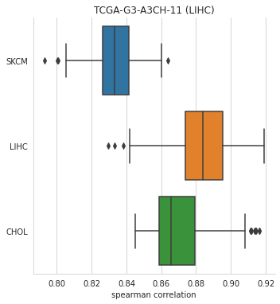

As expected, the average pairwise correlation is highest within the same disease cohort as the sample

## Principle Component Analysis (PCA)

The principal component analysis would serve a similar function to the pairwise spearman correlations plot above and could be included in place of said plot if preferred. For this we will need to install more python libraries

```
!pip install scikit-learn
```

Now we are ready to set up the PCA model.

```
from sklearn.decomposition import PCA

pca = PCA()
```

Our input to the PCA model is a matrix with each sample as a row. Since in our current matrix the genes are rows we need to transpose this

```
X = exp_matrix.T
X
```

| gene | ENSG00000242268.2 | ENSG00000259041.1 | ENSG00000270112.3 | ENSG00000167578.16 | ENSG00000278814.1 | ENSG00000078237.5 | ENSG00000269416.5 | ENSG00000263642.1 | ENSG00000146083.11 | ENSG00000158486.13 | ENSG00000273639.4 | ENSG00000198242.13 | ENSG00000231981.3 | ENSG00000269475.2 | ENSG00000134108.12 | ENSG00000261030.1 | ENSG00000172137.18 | ENSG00000276644.4 | ENSG00000240423.1 | ENSG00000271616.1 | ENSG00000234881.1 | ENSG00000236040.1 | ENSG00000231105.1 | ENSG00000094963.13 | ENSG00000182141.9 | ENSG00000280143.1 | ENSG00000251334.2 | ENSG00000231112.1 | ENSG00000258610.1 | … |
| --- | --- | --- | --- | --- | --- | --- | --- | --- | --- | --- | --- | --- | --- | --- | --- | --- | --- | --- | --- | --- | --- | --- | --- | --- | --- | --- | --- | --- | --- | --- |
| TCGA-G3-A3CH-11 | -9.9658 | -9.9658 | -9.9658 | 3.557200 | -9.9658 | 0.099000 | -9.965800 | -9.9658 | 1.832300 | -9.96580 | -9.9658 | 8.372500 | -9.9658 | -9.9658 | 3.502200 | -9.9658 | -9.965800 | -1.148800 | -9.9658 | -9.9658 | -9.9658 | -9.9658 | -9.965800 | -1.086200 | -1.117200 | -1.214200 | -9.9658 | -9.9658 | 0.84880 | … |
| TCGA-RP-A695-06 | -9.9658 | -9.9658 | -9.9658 | 5.230800 | -9.9658 | 3.092700 | -9.965800 | -9.9658 | 3.201800 | -3.45800 | -9.9658 | 10.228500 | -9.9658 | -9.9658 | 5.436700 | -9.9658 | -1.994200 | -5.573500 | -9.9658 | -9.9658 | -9.9658 | -9.9658 | -5.011600 | -2.465900 | -0.284500 | 0.566600 | -9.9658 | -9.9658 | 1.18330 | … |
| TCGA-DD-AAW0-01 | -9.9658 | -9.9658 | -9.9658 | 4.607700 | -9.9658 | 2.646400 | -4.293400 | -9.9658 | 3.808500 | -4.29340 | -9.9658 | 8.705700 | -9.9658 | -9.9658 | 4.635200 | -9.9658 | -9.965800 | -1.780900 | -9.9658 | -9.9658 | -9.9658 | -9.9658 | -9.965800 | 0.783200 | 0.215400 | 0.444700 | -9.9658 | -9.9658 | 1.48590 | … |
| TCGA-EE-A17X-06 | -9.9658 | -1.6850 | -9.9658 | 5.574100 | -9.9658 | 3.165300 | -9.965800 | -9.9658 | 2.582800 | -6.50640 | -9.9658 | 10.009000 | -9.9658 | -9.9658 | 4.784600 | -9.9658 | -2.314700 | -4.608200 | -9.9658 | -9.9658 | -9.9658 | -9.9658 | -5.011600 | -2.314700 | -0.338300 | -0.249800 | -9.9658 | -9.9658 | 0.64250 | … |
| TCGA-DD-AACA-02 | -9.9658 | -9.9658 | -9.9658 | 4.080749 | -9.9658 | -2.114057 | 0.407079 | -9.9658 | 3.499608 | -3.62591 | -9.9658 | 10.322895 | -9.9658 | -9.9658 | 4.162807 | -9.9658 | -4.442233 | -3.921375 | -9.9658 | -9.9658 | -9.9658 | -9.9658 | -5.965822 | -3.717877 | 0.276236 | -0.619235 | -9.9658 | -9.9658 | 0.79993 | … |
| ... | ... | ... | ... | ... | ... | ... | ... | ... | ... | ... | ... | ... | ... | ... | ... | ... | ... | ... | ... | ... | ... | ... | ... | ... | ... | ... | ... | ... | ... | … |
| TCGA-EE-A2GN-06 | -9.9658 | -9.9658 | -4.2934 | 3.773000 | -9.9658 | 3.740000 | -2.826200 | -9.9658 | 4.802200 | -2.46590 | -9.9658 | 11.006800 | -9.9658 | -9.9658 | 5.737700 | -9.9658 | -2.314700 | -3.046900 | -9.9658 | -9.9658 | -9.9658 | -9.9658 | -3.307600 | -1.469900 | 0.723300 | 0.888300 | -9.9658 | -9.9658 | 1.88790 | … |
| TCGA-D9-A4Z6-06 | -9.9658 | -9.9658 | -9.9658 | 5.684600 | -9.9658 | 3.996500 | -6.506400 | -9.9658 | 4.482900 | -2.05290 | -9.9658 | 10.159600 | -9.9658 | -9.9658 | 4.879800 | -9.9658 | -0.284500 | -2.932400 | -9.9658 | -9.9658 | -9.9658 | -9.9658 | -4.293400 | -1.639400 | 1.098300 | -0.087700 | -9.9658 | -9.9658 | 1.26960 | … |
| TCGA-EE-A29L-06 | -4.6082 | -9.9658 | -9.9658 | 5.281700 | -9.9658 | 4.370200 | -6.506400 | -9.9658 | 3.438400 | -9.96580 | -9.9658 | 10.427600 | -9.9658 | -9.9658 | 6.153200 | -9.9658 | -5.573500 | -5.011600 | -9.9658 | -9.9658 | -9.9658 | -2.1779 | -6.506400 | -1.181100 | 2.046500 | -1.430500 | -9.9658 | -9.9658 | -0.43250 | … |
| TCGA-DD-A115-01 | -9.9658 | -9.9658 | -9.9658 | 4.026000 | -9.9658 | 2.154100 | -1.318300 | -9.9658 | 3.260200 | -4.03500 | -3.8160 | 9.137500 | -9.9658 | -4.6082 | 4.263100 | -9.9658 | -5.573500 | -3.307600 | -9.9658 | -9.9658 | -9.9658 | -9.9658 | -5.573500 | -0.042500 | -0.375200 | 0.240000 | -9.9658 | -9.9658 | 2.28130 | … |
| TCGA-FV-A3I0-11 | -9.9658 | -9.9658 | -9.9658 | 3.087600 | -9.9658 | -0.575600 | -9.965800 | -9.9658 | 1.692000 | -9.96580 | -9.9658 | 8.292000 | -9.9658 | -9.9658 | 3.569400 | -9.9658 | -5.011600 | -2.388400 | -9.9658 | -9.9658 | -9.9658 | -9.9658 | -9.965800 | -1.595100 | -1.994200 | -0.687300 | -9.9658 | -9.9658 | -0.32010 | … |

936 rows × 60498 columns

Now we are ready to fit the PCA

```
fit = pca.fit(X)
fit
```

```
PCA(copy=True, iterated_power='auto', n_components=None, random_state=None,
    svd_solver='auto', tol=0.0, whiten=False)
```

Plot the explained variance by the number of components for any components that explain at least 0.5% of the variance

```
components_df = pd.DataFrame(enumerate(fit.explained_variance_ratio_), columns=['component', 'variance_explained'])
components_df['cum_var'] = components_df.variance_explained.cumsum()
components_df
```

|  | component | variance_explained | cum_var |
| --- | --- | --- | --- |
| 0 | 0 | 2.098103e-01 | 0.209810 |
| 1 | 1 | 4.941317e-02 | 0.259223 |
| 2 | 2 | 2.684464e-02 | 0.286068 |
| 3 | 3 | 2.096802e-02 | 0.307036 |
| 4 | 4 | 1.821842e-02 | 0.325255 |
| ... | ... | ... | ... |
| 931 | 931 | 2.724521e-04 | 0.999199 |
| 932 | 932 | 2.708955e-04 | 0.999470 |
| 933 | 933 | 2.679152e-04 | 0.999738 |
| 934 | 934 | 2.619554e-04 | 1.000000 |
| 935 | 935 | 2.545080e-28 | 1.000000 |

936 rows × 3 columns

```
fig = sns.relplot(data=components_df[components_df.variance_explained >= 0.005], x='component', y='variance_explained', kind='line')
fig.set(xlabel='Component #', ylabel='Proportion of Variance Explained')
```

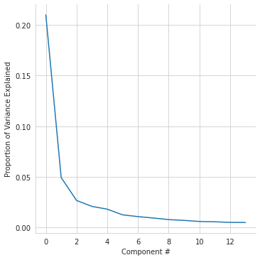

If we want to see the variance explained as we keep X components we can plot that as well

```
fig = sns.relplot(data=components_df, x='component', y='cum_var', kind='line')
fig.set(xlabel='Number of Components', ylabel='Proportion of Variance Explained')
```

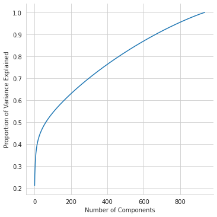

To visualize this in 2-d we can only plot the first two components

```
pca_xy = PCA(n_components=2)
fit_xy = pd.DataFrame(pca_xy.fit_transform(X), index=X.index, columns=['component 1', 'component 2'])
fit_xy
```

|  | component 1 | component 2 |
| --- | --- | --- |
| TCGA-G3-A3CH-11 | 313.877223 | 58.038358 |
| TCGA-RP-A695-06 | -178.026704 | 152.348532 |
| TCGA-DD-AAW0-01 | 205.633995 | -104.460686 |
| TCGA-EE-A17X-06 | -185.690333 | 172.857407 |
| TCGA-DD-AACA-02 | 226.342307 | -60.439144 |
| ... | ... | ... |
| TCGA-EE-A2GN-06 | -253.444806 | 21.297225 |
| TCGA-D9-A4Z6-06 | -243.644653 | 27.199689 |
| TCGA-EE-A29L-06 | -220.859424 | 123.556796 |
| TCGA-DD-A115-01 | 250.808496 | -44.392051 |
| TCGA-FV-A3I0-11 | 375.594610 | 127.824032 |

936 rows × 2 columns

Now join this back to the metadata to get the groupings

```
fig_df = fit_xy.reset_index().rename(columns={'index': 'sample'}).merge(meta_df, on=['sample'], how='left')
fig_df[['sample', 'component 1', 'component 2', 'cancer type abbreviation']]
```

|  | sample | component 1 | component 2 | cancer type abbreviation |
| --- | --- | --- | --- | --- |
| 0 | TCGA-G3-A3CH-11 | 313.877223 | 58.038358 | LIHC |
| 1 | TCGA-RP-A695-06 | -178.026704 | 152.348532 | SKCM |
| 2 | TCGA-DD-AAW0-01 | 205.633995 | -104.460686 | LIHC |
| 3 | TCGA-EE-A17X-06 | -185.690333 | 172.857407 | SKCM |
| 4 | TCGA-DD-AACA-02 | 226.342307 | -60.439144 | LIHC |
| ... | ... | ... | ... | ... |
| 931 | TCGA-EE-A2GN-06 | -253.444806 | 21.297225 | SKCM |
| 932 | TCGA-D9-A4Z6-06 | -243.644653 | 27.199689 | SKCM |
| 933 | TCGA-EE-A29L-06 | -220.859424 | 123.556796 | SKCM |
| 934 | TCGA-DD-A115-01 | 250.808496 | -44.392051 | LIHC |
| 935 | TCGA-FV-A3I0-11 | 375.594610 | 127.824032 | LIHC |

936 rows × 4 columns

Add a flag column for our sample of interest

```
fig_df.loc[fig_df['sample'] == test_sample_id, 'target sample'] = True
fig_df['target sample'] = fig_df['target sample'].fillna(False)
fig_df[['sample', 'component 1', 'component 2', 'cancer type abbreviation', 'target sample']]
```

|  | sample | component 1 | component 2 | cancer type abbreviation | target sample |
| --- | --- | --- | --- | --- | --- |
| 0 | TCGA-G3-A3CH-11 | 313.877223 | 58.038358 | LIHC | True |
| 1 | TCGA-RP-A695-06 | -178.026704 | 152.348532 | SKCM | False |
| 2 | TCGA-DD-AAW0-01 | 205.633995 | -104.460686 | LIHC | False |
| 3 | TCGA-EE-A17X-06 | -185.690333 | 172.857407 | SKCM | False |
| 4 | TCGA-DD-AACA-02 | 226.342307 | -60.439144 | LIHC | False |
| ... | ... | ... | ... | ... | ... |
| 931 | TCGA-EE-A2GN-06 | -253.444806 | 21.297225 | SKCM | False |
| 932 | TCGA-D9-A4Z6-06 | -243.644653 | 27.199689 | SKCM | False |
| 933 | TCGA-EE-A29L-06 | -220.859424 | 123.556796 | SKCM | False |
| 934 | TCGA-DD-A115-01 | 250.808496 | -44.392051 | LIHC | False |
| 935 | TCGA-FV-A3I0-11 | 375.594610 | 127.824032 | LIHC | False |

936 rows × 5 columns

```
fig = sns.relplot(kind='scatter', data=fig_df, x='component 1', y='component 2', hue='cancer type abbreviation')
```

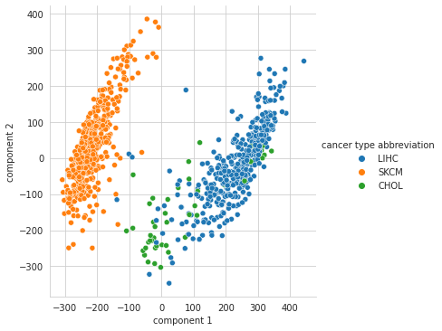

Add the annotation to pick out our current sample in the PCA. We are going to plot overtop of the original plot to accomplish this

```
ax = sns.scatterplot(data=fig_df, x='component 1', y='component 2', hue='cancer type abbreviation', alpha=0.5)
ax = sns.scatterplot(data=fig_df[fig_df['sample'] == test_sample_id], x='component 1', y='component 2', marker='X', alpha=1, ax=ax, color='black', s=300)
```

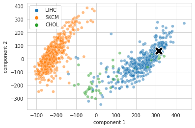

As we saw with the correlation plot, the LIHC sample is grouped with its disease cohort

Back to top